# act_report

## Report: act_report

- Create a **250-word-minimum written report** called "act_report.pdf" or "act_report.html" that communicates the insights and displays the visualization(s) produced from your wrangled data. This is to be framed as an external document, like a blog post or magazine article, for example.

> Analysis and Visualization Report

With 3 different datasets provided, we worked on gathering all datasets, assessed and cleaned the data, we merged the 3 datasets int 1 large dataset, to visually have an observation and understanding of what the data could mean.

> **CLEANING PROCESS**
> - This process really needed patience and understanding of what you want to achieve because as soon as I solve an issue I would encounter another and the process gave me insight on how to solve some of the common issues I would come across when I run a project on the platform. Process imcluded;
> - **Define:** Specify what I untend to clean and document the step.
> - **Code:** Show the code used to archive the task I am facing.
> - **Test:** Displaying the results of what the code has done(see if it was a success or not)

> **Plot bar graph to display twitter sources:**
> - Below the bar graph displays the majority of twitter source come from "twitter for iPhone"

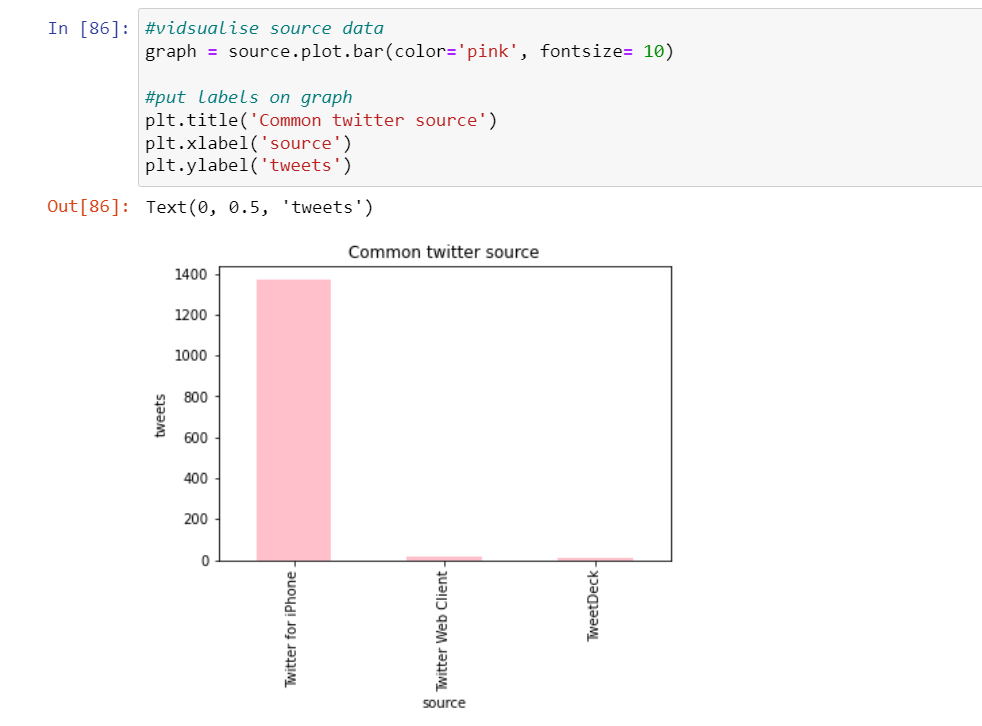

> **Plot WordCloud to display dog names:**
> - WordCloud is a very interesting way to display words and so I chose to use it to display dog names with the largest words being the most common / popular and smallest words being the least common / popular, I also tried to add an image for custom mast to give the visuals more character but unfotunately that is something I still need to get right. Looking at the visuals we can conclude that Charlie, Cooper, Oliver are quite popular.

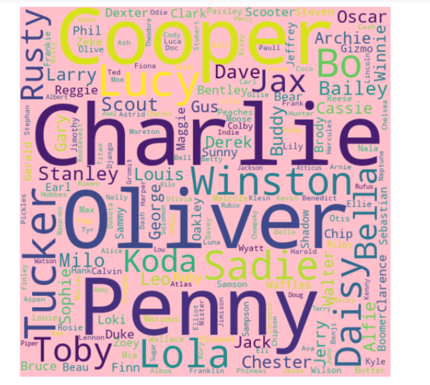

> **Plot a scatter chart for retweets vs favorite:**
> - Finally we looked at the correlation between retweets and favorite to see if tweets that are favorited are also retweeted and the plot is positive to show that favorite tweets and retweeted tweets go move the same direction.

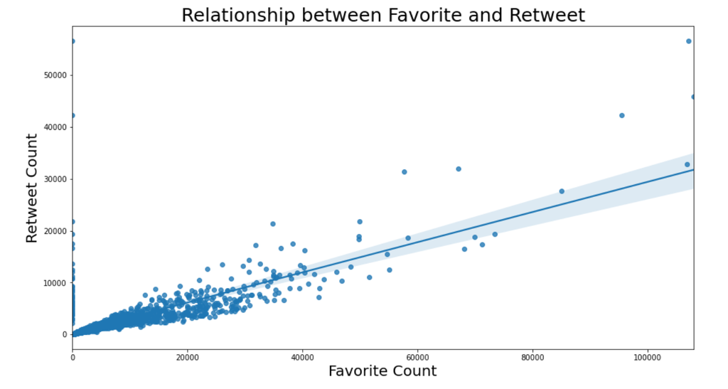